# Marketing Analytics - Class 4 Data Wrangling with R Part I

Author

Dr Wei Miao

Published

October 13, 2022

# 1 Overview

## 1.1 Class Objectives

- Understand the major steps to conduct data analytics
- **Data collection:** Learn how to collect first-hand data
- **Data cleaning:** Learn how to use the `dplyr` package to collect, load, and clean data
- **Data analysis:** Learn how to conduct descriptive analytics

# 2 Data Analytics Workflow

## 2.1 Overview

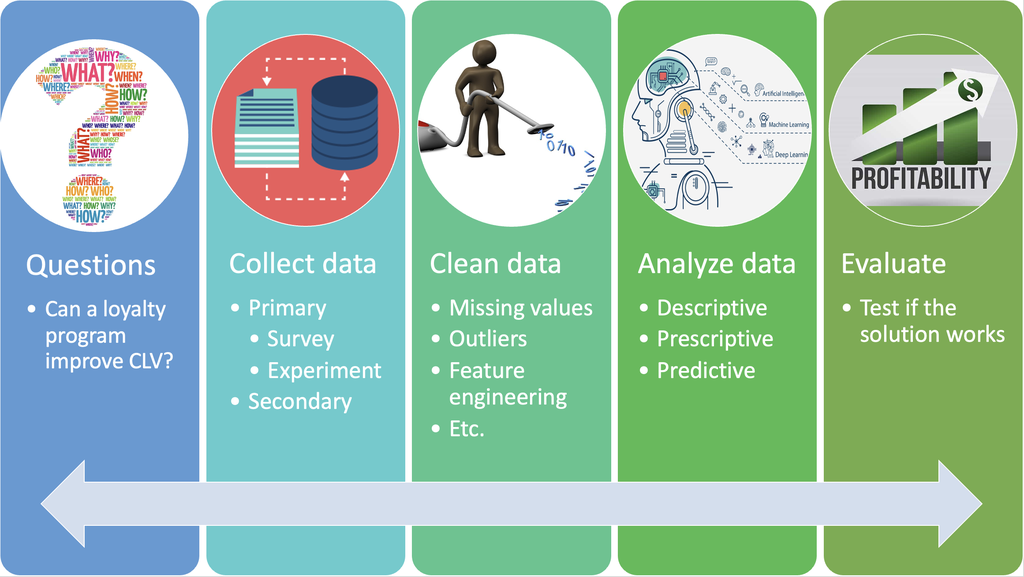

## 2.2 Collect Data

- **Primary Data:** Data that are generated by the researcher himself/herself, surveys, interviews, experiments, specially designed for understanding and solving the research problem at hand.
- **Secondary Data:** Existing data generated by the company’s or consumer’s past activities, as part of organizational record keeping.

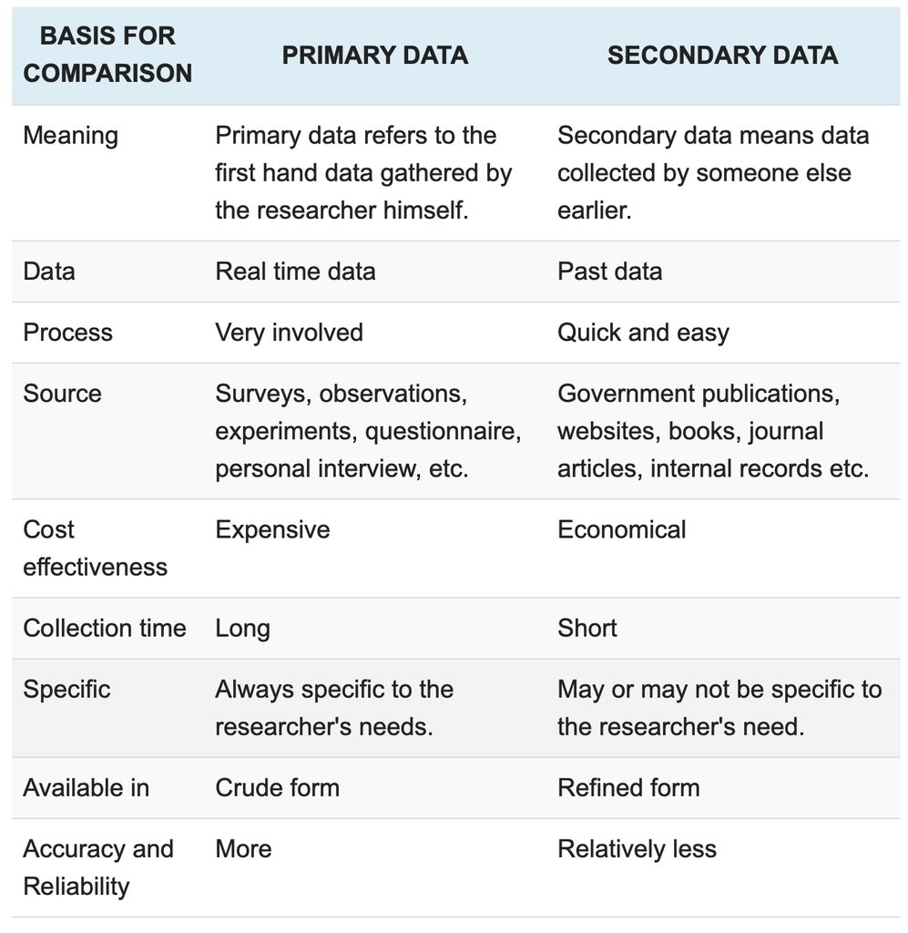

## 2.3 Collect Data: Marketing Surveys

- In a marketing survey, we typically would like to solicit the following
  - purchase intention
  - willingness to pay (WTP)
  - shopping basket
  - share of wallet (SoW)
  - demographics
- **Let’s see an example of how to design a simple marketing survey!**
- Useful supplementary readings if you need to design marketing surveys
  - [The quick start guide on how to conduct market research](https://www.surveymonkey.co.uk/mp/market-research-surveys/)